# REANIMAÇÃO DO RN EM SALA DE PARTO ROTINAS HRT CARLOS HENRIQUE

**REANIMAÇÃO NEONATAL (para maiores de 34 semanas)**

A atenção ao recém-nascido, imediatamente após o nascimento é uma etapa importante para garantia da vitalidade do bebê e a asfixia uma causa notável de mortalidade neonatal em todo o mundo. Desta maneira, os profissionais, que atuam nestes ambientes, precisam estar preparados para reconhecer qualquer situação comprometedora e, se necessário, realizar as manobras de reanimação neonatal.

A Sociedade Brasileira de Pediatria, baseado em protocolos da Academia Americana de Pediatria, sugere intervenções que garantam a permeabilidade de vias aéreas e manutenção da temperatura corpórea, bem como circulação adequada e respiração eficaz, desde o nascimento.

- **Preparo para assistência:**

O preparo para assistência deve levar em conta a antecipação de riscos. De uma forma geral esta antecipação é suportada por três aspectos principais: A história de vida desta criança, que se inicia antes mesmo do nascimento, com ênfase à história materna prévia e gestacional; existência de material adequado para a assistência completa dos recém nascidos e a existência de uma equipe preparada para executar todos os procedimentos necessários a uma eventual reanimação neonatal.

**História de vida do concepto, com ênfase à história materna:**

É conveniente que, antes do parto, existam registros sobre a saúde materna prévia e gestacional, além da elaboração de uma boa história perinatal. Com isto, busca-se identificar fatores de risco que possam levar a necessidade de uma atenção específica no pós-parto imediato ou mediato. Com frequência, um maior risco de necessidade de reanimação neonatal está ligado a fatores relacionados a características maternas e do parto.

**Existência de material adequado para a assistência completa dos recém nascidos:**

É fundamental que os equipamentos necessários para reanimação estejam sempre disponíveis e testados antes da ocorrência de qualquer nascimento, sendo acessível sua localização. Para se prevenir imprevistos, sempre que se chegar ao ambiente do parto, todos os equipamentos dever ser checados, mesmo que não seja a primeira intervenção realizada naquele período. Os materiais, de maneira geral se destinam a manutenção da temperatura do RN, liberação das vias aéreas e ventilação adequada e material para administração de medicações, além dos materiais de biossegurança.

**Existência de uma equipe preparada para executar todos os procedimentos necessários**:

Durante a assistência ao parto, é fundamental a presença de pelo menos um profissional capaz de realizar a reanimação adequadamente. Quando se menciona profissional capaz, se faz menção a um preparo técnico (cognitivo), mas também a uma condição emocional segura no momento da assistência. Manter o ambiente em condições favoráveis, mesmo em situações extremamente negativas faz parte das atribuições do líder da reanimação. Uma liderança técnica e emocionalmente adequada poderá instrumentalizar aos auxiliares que estiverem presentes para uma reanimação bem-sucedida. Os auxiliares atuando junto ao líder devem estar dedicados exclusivamente a um reanimando. Em casos de recém-nascidos gêmeos, deve haver uma equipe exclusiva assistência individual de cada criança.

**Cuidados com o recém-nascido maior ou igual a 34 semanas:**

Segundo as diretrizes atuais da Organização Mundial da Saúde, recomenda-se, para recém-nascidos ≥ 34 semanas com respiração adequada e tônus muscular em flexão ao nascimento, clampear o cordão umbilical entre 1 e 3 minutos depois da sua saída completa do claustro uterino. O neonato pode ser posicionado no abdome ou tórax materno durante esse periodo. Já para os casos onde a circulação placentária não esteja intacta (descolamento prematuro de placenta, placenta prévia, rotura placentária, prolapso ou nó verdadeiro de cordão) ou naqueles onde os recém-nascidos ≥ 34 semanas não iniciem respiração efetiva ou não demonstrem tônus muscular em flexão, recomenda-se o clampeamento imediato do cordão.

Quando, ao nascimento, o recém-nascido for de termo e apresentar boa vitalidade, deverá continuar junto de sua mãe depois do clampeamento do cordão umbilical. Esta aproximação ajuda na recuperação da mãe, tranquilizando-a e estimulando também na produção do leite. O contato pele-a-pele entre mãe e bebê favorece o início precoce da amamentação e aumenta a chance do aleitamento materno exclusivo prolongado além de assegurar que o recém-nascido receba, a partir do colostro, diversos fatores protetores ainda na primeira hora pós-parto.

No momento do pós-parto imediato, enquanto o RN estiver junto à sua mãe, será imprecindível a provisão de calor, manutenção da permeabilidade das vias aéreas e a avaliação de sua vitalidade de maneira continuada.

Por outro lado, pacientes com idade gestacional diferente do termo; recém-nascidos que não iniciam movimentos respiratórios regulares e/ou aqueles em que o tônus muscular está flácido serão conduzidos a mesa de reanimação. Ao chegar a mesa de reanimação, instituem-se os passos iniciais da estabilização, na seguinte sequência: oferta de calor; posicionamento da cabeça em leve extensão; aspiração de boca e narinas (se necessário) e secagem do RN, com retirada dos campos úmidos imediatamente. Tais passos devem ser executados em, no máximo, 30 segundos.

O RN deverá ser levado a mesa de reanimação envolto em campos aquecidos e posicionado sob calor radiante, em decúbito dorsal, com a cabeça voltada para o profissional de saúde. A mesa de reanimação não deve ter qualquer inclinação. Apesar da provisão de calor, deve-se tomar cuidado especial para evitar a hipertermia (> 37,5 <sup>o</sup>C), pois pode agravar a lesão cerebral em pacientes asfixiados.

A fim de assegurar a permeabilidade das vias aéreas, após o posicionamento adequado do recém nascido (pescoço em leve extensão, mas sem hiperextensão ou flexão exagerada, muitas vezes obtida com uso de um coxim sob os ombros) pode ser procedida a aspiração, que, contudo, está reservada a pacientes que apresentam obstrução de vias aéreas por excesso de secreções. Deve-se evitar a introdução da sonda de aspiração de maneira brusca ou na faringe posterior, pois pode induzir à resposta parasimpática com espasmo laríngeo, sialorréia, apneia e bradicardia.

No caso de bebês que necessitarem ser conduzidos à mesa de reanimação, por não serem de termo; por não apresentarem respiração regular ou ainda por hipotonia, recomenda-se, na presença de líquido amniótico meconial, a aspiração de boca e narinas, com sonda de aspiração calibrosa (no 10).

Para os recém nascidos em que foram realizados os passos iniciais da estabilização e a avaliação com se mantiver com respiração inefetiva e/ou FC <100 bpm, iniciar a VPP nos primeiros 60 segundos após o nascimento e acompanhar a FC pelo monitor cardíaco e a saturação de oxigênio (SatO<sub>2</sub>) pelo oxímetro de pulso.

**Assistência ao RN com líquido amniótico meconial:**

Ao contrario do preconizado anteriormente, na vigência de líquido amniótico meconial, independentemente de sua viscosidade, a aspiração das vias aéreas ao desprendimento do polo cefálico do concepto não deve mais ser realizada. Segue-se sequência prevista para aqueles sem a presença de mecônio.Também para os recém nascidos, com líquido amniótico meconial de qualquer viscosidade, levados à mesa de reanimação para os passos iniciais, que apresentem apneia, respiração irregular e/ou FC < 100 bpm, é fundamental iniciar a VPP com máscara facial e ar ambiente nos primeiros 60 segundos de vida. Se após 30 segundos de ventilação efetiva, o neonato não melhora e há forte suspeita de obstrução de vias aéreas, indica-se a retirada do mecônio residual da hipofaringe e da traqueia sob visualização direta. A aspiração traqueal propriamente dita é feita através da cânula traqueal conectada a um dispositivo para aspiração de mecônio e ao aspirador a vácuo. Nessa situação, aspirar o excesso de mecônio uma única vez, já que há necessidade do início rápido da ventilação em todo RN que não apresente respiração regular ou esteja bradicárdico no 1<sup>o</sup> minuto após o nascimento.

**Ventilação com pressão positiva (VPP):**

O ponto crítico para o sucesso da reanimação é a ventilação adequada, fazendo com que os pulmões se inflem permitindo dilatação da vasculatura pulmonar e hematose apropriada. Assim, após os cuidados para manter a temperatura e a permeabilidade das vias aéreas do RN, a presença de apneia, respiração irregular e/ou FC <100 bpm indica a VPP. que precisa ser iniciada nos primeiros 60 segundos de vida. A ventilação pulmonar é o procedimento mais simples, importante e efetivo na reanimação do RN em sala de parto.

**Oxigênio suplementar:**

Se indicada, a VPP para recém nascidos ≥ 34 semanas deverá ser feita inicialmente com com ar ambiente (oxigênio a 21%). Iniciada a ventilação, recomenda-se o uso da oximetria de pulso pré-ductal para monitorar a oferta do oxigênio suplementar. Se houver débito cardíaco suficiente para manter a perfusão periférica, a leitura confiável da SatO<sub>2</sub> demorará cerca de 1 a 2 minutos após o nascimento. Salienta-se que o processo de transição normal para alcançar uma SatO<sub>2</sub> > 90% requer cerca de 5 minutos ou mais em RN saudáveis que respiram ar ambiente.

| **Minutos de Vida** | **Saturação pré-ductal** |
| --- | --- |
| Até 5 minutos | 70 a 80% |
| Entre 5 e 10 minutos | 80 a 90% |
| Após 10 minutos | 85 a 95% |

Tabela 1: Valores de saturação desejáveis, segundo idade pós natal.

A monitorização da Saturação de O<sub>2</sub> possibilita o uso criterioso e racional de oxigênio. Assim, quando o recém nascido não melhora e/ou não atinge os valores desejáveis de SatO<sub>2</sub> com a VPP em ar ambiente, recomenda-se sempre verificar e corrigir a técnica da ventilação antes de oferecer oxigênio suplementar. A necessidade de oxigênio suplementar é excepcional em RN ≥ 34 semanas se a VPP é feita com a técnica adequada. Nos poucos casos em que isto é necessário, indica-se a aplicação da mistura O<sub>2</sub>/ar comprimido, ajustando-se a concentração minima necessária de oxigênio, por meio de um blender, para atingir a SatO<sub>2</sub> alvo. Diante de qualquer modificação da FIO<sub>2</sub> ofertada, é necessário um período de cerca de 30 segundos para haver equilíbrio da concentração de oxigênio por toda a área pulmonar do RN. Por tal razão, sugere-se, que nos raros pacientes em que há necessidade de oxigênio suplementar durante a ventilação, fazer incrementos de 20% e aguardar cerca de 30 segundos para verificar a SatO<sub>2</sub> e indicar novos incrementos, ressaltando-se que a VPP com a técnica correta é fundamental para a melhora do paciente.

**Equipamentos para a ventilação:**

Apesar de não permitir PEEP, o balão autoinflável é de baixo custo, sendo o único equipamento de ventilação em sala de parto que não necessita de fonte de gás comprimido para funcionar. Neste, a pressão inspiratória máxima é variável, e apenas será conhecida na existência de manômetro, não disponível nos modelos no HRT. A pressão inspiratória deverá ser limitada, pela válvula de escape, calibrada para ser ativada em torno de 30-40 cm de água, para evitar o barotrauma. Na ausência do uso do blender, um balão autoinflável fornece concentração de oxigênio de 21% (ar ambiente, quando não está conectado ao oxigênio), de FiO<sub>2</sub> variável (se conectado apenas à fonte de oxigênio, a depender do fluxo usado, marca do balão, pressão e frequência das compressões, bem como da força execida e tempo de compressão do balão) e 90 - 100% (quando conectado ao oxigênio e a um reservatório).

O ventilador mecânico manual de fluxo contínuo, é controlado a fluxo e limitado a pressão. Para o funcionamento do ventilador há necessidade de uma fonte de gás comprimida. A concentração de oxigênio ao paciente pode ser titulada quando o equipamento está ligado ao blender ou pelo conhecimento da mistura gasosa oferecida a partir do cálculo dos fluxos de ar e oxigênio utilizadas. O manuseio de tal ventilador, permite ajustar/administrar pressão inspiratória e pressão expiratória, no final da expiração, constantes, de acordo com a resposta clínica do RN, além de permitir a aplicação de CPAP nos pacientes que respiram espontaneamente.

FiO<sub>2</sub> = [(qtde. litros de Ar comprimido x 21) + (qtde. litros de O<sub>2</sub> x 100)]/total de litros da mistura.

Ex: FiO<sub>2</sub> de um dispositivo de ventilação (balão auto inflável ou ventilador de fluxo contínuo) sendo usado com 1 litro0 de oxigênio e 4 de ar acomprimido.

FiO<sub>2</sub> = [(4x21) + (1x100)] / 5 = 36%

A interface entre o equipamento para ventilação e o RN ≥ 34 semanas, pode-se ser feita por meio de mascaras (facial ou laríngea) e por cânula traqueal. As mascaras são disponíveis em três tamanhos (para o RN termo, prematuro e para o prematuro extreme) e devem possibilitar a cobertura da ponta do queixo, a boca e nariz. Já as cânulas traqueais devem ser de diâmetro uniforme, sem balão, com linha radiopaca e marcador de corda vocal.

**VPP por meio da máscara facial:**

Sendo o procedimento mais simples e efetivo na reanimação do recém nascido em sala de parto, estará indicada na presença de apneia, respiração irregular e/ou FC <100 bpm, após os passos iniciais. É fundamental, contudo, que seja iniciada ainda nos primeiros 60 segundos de vida, perído conhecido identificado como “Minuto de Ouro”. Nos bebês ≥ 34 semanas, a ventilação com balão autoinflável ou ventilador mecânico manual de fluxo contínuo deve ser iniciada preferencialmente por meio de máscara facial.

Após posicionar adequadamente o recém nascido (pescoço em leve extensão) e aplicar a máscara na face (do queixo até o nariz), deve-se envolver as bordas da máscara com os dedos indicador e polegar, formando a letra “C”, para fixá-la na região correta, com uma leve pressão em sua borda. Ainda para se obter uma boa ventilação, os dedos médio, anular e mínimo formam a letra “E”, mantendo a permeabilidade das vias aéreas.

A frequência indicada para a ventilação com balão autoinflável e máscara é de 40-60 movimentos/minuto, sendo um tempo usado para inspiração e dois para a expiração (“aperta/solta/solta”). A pressão a ser aplicada deve ser individualizada para que o RN alcance e mantenha FC >100 bpm. De modo geral, iniciar com pressão inspiratória ao redor de 20 cm de água, sendo raramente necessário alcançar 30-40 cm de água para pacientes com pulmões imaturos ou doentes. Após as cinco primeiras ventilações, é prudente reajustar a pressão inspiratória de modo a visualizar o movimento torácico leve e auscultar a entrada de ar nos pulmões.

Se optado pelo o uso do ventilador mecânico de fluxo contínuo, é necessário fixar um fluxo gasoso (entre 5 e 15 L/minuto), limitar a pressão máxima do circuito (30 a 40 cm de água), selecionar a pressão inspiratória a ser aplicada em cada ventilação (20 a 25 cm de água), e ajustar a PEEP (5 cm de água). Da mesma maneira que com o uso do balão auto inflável, após as cinco primeiras ventilações, deverá ser reajustada a pressão inspiratória, mantendo-se contudo, a ventilação efetiva, com FR entre 40 e 60 ipm.

A ventilação objetiva uma adequada expansão pulmonar, sem levar à superdistensão. Portanto, durante este procedimento, o executante deve ser capaz de detectar e corrigir possíveis falhas de adaptação do material e da técnica usada, que possam interferir na permeabilidade das vias aéreas e uso de pressão adequada, de modo rápido. Para tal, é preciso monitorar a FC, a respiração e a SatO<sub>2</sub>. O indicador mais importante de que a VPP está sendo efetiva é o aumento da FC. Uma ventilação efetiva deve provocar inicialmente a elevação da FC e, depois, o estabelecimento da respiração espontânea. Se, após 30 segundos de VPP com máscara, o paciente apresentar FC >100 bpm e respiração espontânea e regular, suspender o procedimento.

Da mesma forma, considera-se como falha se, após 30 segundos de VPP com máscara, o RN mantém FC < 100 bpm ou não retoma a respiração espontânea rítmica e regular. Apenas se houver certeza do uso de material e técnica adequadas, a falha deverá ser rebatida com oferta crescente de oxigênio suplementar. A necessidade de oxigênio suplementar é excepcional em RN ≥ 34 semanas, se a VPP é feita com a técnica adequada.

Se o paciente, após a correção da técnica da ventilação e elvação da FiO<sub>2</sub> ofertada, não melhorar está indicado o uso da cânula traqueal como interface para a ventilação com pressão positiva. Recomenda-se, contudo, que durante períodos prolongados de ventilação com máscara, seja inserida uma sonda orogástrica para descompressão gástrica, causada pela aerofagia.

**VPP por meio da cânula traqueal :**

Estará indicada a ventilação com pressão positiva sob cânula traqueal em sala de parto quando a ventilação com máscara facial não for efetiva e/ou quando houver necessidade de massagem cardiaca externa. Além dessas situações, a intubação traqueal e a inserção imediata de sonda gástrica são indicadas nos pacientes portadores de hérnia diafragmática que necessitarem de ventilação com pressão positiva.

| **Idade Gestacional** | **Peso estimado** | **Tamanho do diâmetro interno da cânula traqueal** |
| --- | --- | --- |
| 34-38 semanas | 2000-3000g | 3,5mm |
| >38 semanas | >3000g | 3,5-4,0mm |

Tabela 2: Tamanho de cânulas traqueais para > 34 semanas, segundo idade

Gestacional (IG) e/ou peso estimado.

Obs: Deixar sempre à disposição uma cânula de diâmetro superior e outra inferior àquela escolhida.

É prudente que cada tentativa de intubação dure, no máximo, 30 segundos, com ventilação por máscara, até a estabilização do paciente antes de realizada nova tentativa.

O posicionamneto adequado da cânula deve ser sempre realizado, principlamente na vigência de bradicardia não responsiva às medidas de reanimação. Além da resposta em elevação da FC, são usados como indicadores a inspeção da expansibilidade torácica, ausculta das regiões de maior aeração (apices e regiões axilares) e da região gástrica, para reconecimento de intubação indvertida do esôfago. Em caso de necessidade de permanência da intubação, a localização radiográfica da cânula deverá ser procedida o mais rápido possível, nunca, contudo interferindo ou retardamendo as manobras de reanimação.

Na sala de parto, recomenda-se usar a regra prática “peso estimado (kg) + 6” para calcular o comprimento da cânula a ser inserido na traqueia, sendo o resultado correspondente à marca, em centímetros, a ser fixada no lábio superior. Pode-se ainda utilizar a idade gestacional para calcular o comprimento da cânula a ser inserido na traqueia, considerando a distância entre a ponta da cânula e a marca, em centímetros, a ser fixada no lábio superior. Para a localização radiográfica, a ponta distal da cânula deve estar localizada no terço médio da traqueia, na altura da 1<sup>a.</sup> vértebra torácica.

| **Idade Gestacinal** | **Marca (cm) a ser considerada no lábio superior, para fixação** |
| --- | --- |
| 34 semanas | 7,5 cm |
| 35 a 37 semanas | 8,0 cm |
| 38 a 40 semanas | 8,5 cm |
| 41 ou mais semanas | 9,0 cm |

Tabela 3: Comprimento da cânula a ser inserida na traquela, segundo IG

Após a intubação, inicia-se a ventilação com balão autoinflável ou com ventilador mecânico de fluxo contínuo na mesma frequência (40 a 60 ipm) e pressão (ao redor de 20 cm de água) descritas para a ventilação com mascara, contudo deve-se proceder os ajustes individualizados observando-se a expansibilidade torácica e a manutenção de uma FC >100 bpm.

Quanto ao uso de oxigênio suplementar durante a VPP por meio da cânula traqueal, quando a intubação foi indicada por ventilação com máscara facial inadequada (a tentativa de correção da técnica da VPP não foi bem sucedida), é possível iniciar a VPP por cânula traqueal com ar ambiente e, após 30 segundos, monitorar a SatO<sub>2</sub>. Com a mesma recomendação de incrementos de 20% em intevalos de pelo menos 30 segundos antes de novas elevações da oferta do oxigênio. Quando, por outro lado, a intubação foi indicada porque o RN permaneceu com FC <100 bpm em ventilação com máscara facial e técnica adequada, a VPP com cânula traqueal pode ser iniciada na mesma concentração de O<sub>2</sub> que estava sendo oferecida antes da intubação, seguindo se a mesma recomendação de monitoramento da SatO<sub>2</sub>, após 30 segundos.

A ventilação será suspensa e o paciente extubado se, nas avaliações subsequentes (a cada 30 segundos, da respiração, FC e SatO<sub>2</sub>), houver FC > 100 bpm e movimentos respiratórios espontâneos e regulares. Considera-se como falha se, após 30 segundos de VPP por meio da cânula traqueal, o RN mantém FC <100 bpm ou não retoma a respiração espontânea ou, ainda, se a SatO<sub>2</sub> permanece abaixo dos valores desejáveis/não detectável. Nesses casos, devem ser verificadas e corrigidas possíveis falhas técnicas, em geral relacionadas ao posicionamento da cânula, à permeabilidade das vias aéreas e à pressão que está sendo aplicada. Após essa correção, pode-se aumentar a oferta de oxigênio. Se o RN mantém apneia ou respiração irregular, continuar a ventilação por cânula traqueal. Se a FC está <60bpm, indicar a massagem cardíaca.

**Massagem cardíaca externa (MCE):**

A MCE só é indicada se, após 30 segundos de VPP com técnica adequada, a FC estiver < 60 bpm, uma vez que sua realização diminui a eficácia da ventilação que é a ação mais efetiva na reanimação neonatal. As compressões só devem ser iniciadas quando a expansão e a ventilação pulmonares estiverem bem estabelecidas. Portanto, na reanimação de um RN, não é admissível a realização de MCE antes da melhor aplicação possível da VPP (entubação traqueal, e uso de concentração de oxigênio de 60-100%).

As compressões torácicas são realizadas no terço inferior do esterno, onde se situa a maior parte do ventrículo esquerdo. Podem ser aplicadas as técnicas bimanual ou bidigital. Os dedos serão localizados no terço inferior do esterno, logo abaixo da linha intermamilar e poupando o apêndice xifoide. O restante das mãos circundam o tórax, dando suporte ao dorso durante a massagem. O profissional que vai executar a massagem cardíaca se posiciona atrás da cabeça do RN, enquanto aquele que ventila se desloca para um dos lados. A profundidade da compressão deve correponder a <sup>1</sup>/<sub>3</sub> da dimensão ântero-posterior do tórax, de maneira a produzir um pulso palpável. Após a compressão, é necessário que haja a reexpansão plena do tórax para haver enchimento das câmaras ventriculares e das coronárias, sem que se retire os dedos do tórax. As complicações da massagem cardíaca incluem a fratura de costelas, com pneumotórax e hemotórax, e laceração de fígado.

Se faz importante a sincronia entre os movimentos ventilatórios e a MCE. Desta maneira, o reanimador principal deverá garantir tal sincronicidade. Será mantida uma relação de 3:1 (3 movimentos de MCE para 1 movimento de ventilação). A única situação em que se pode considerar a aplicação de 15 compressões cardíacas intercaladas com 2 ventilações será a de pacientes internados em unidade neonatal, cuja origem da parada cardiorrespiratória seja provavelmente cardíaca, como nos portadores de cardiopatias congênitas.

A reavaliação, durante a MCE, sera feita a cada 60 segundos, pois este é o tempo mínimo para que a massagem cardíaca efetiva possa restabelecer a pressão de perfusão coronariana. O monitor cardíaco é útil, portanto, para avaliar de forma contínua e instantânea a FC, sem interromper a ventilação e a massagem. A massagem deve continuar enquanto a FC estiver < 60 bpm.

A melhora é considerada quando, após a VPP acompanhada de massagem cardíaca por 60 segundos, o RN apresenta FC > 60 bpm. Neste momento, interrompe-se apenas a massagem. A VPP será interrompida apenas quando o paciente apresentar respirações espontâneas regulares com FC >100 bpm.

Considera-se a falha do procedimento se, após 60 segundos de VPP com cânula traqueal e oxigênio a 100% e MCE com adequada técnica de aplicação (sincronia entre ventilação e compressões cardíacas, frequência de compressões adequada, profundidade correta, oferta de um tempo de diástole para o enchimento coronariano e ventricular), o RN mantém FC < 60 bpm. Nesse caso, verificar a posição da cânula, a permeabilidade das vias aéreas e a técnica da ventilação e da massagem, corrigindo o que for necessário. Se, após a correção da técnica da VPP e massagem, não há melhora, considera-se o cateterismo venoso umbilical de urgência e indica-se a adrenalina.

- **Medicações:**

Quando a FC permanece < 60 bpm, a despeito de ventilação efetiva por cânula traqueal com oxigênio a 100% e acompanhada de massagem cardíaca adequada, o uso de adrenalina, expansor de volume ou ambos está indicado. Não está mais recomendado o uso de bicarbonato de sódio, naloxone, atropina, albumina e outros vasopressores na reanimação do RN em sala de parto.

A via preferencial para a infusão de medicações na sala de parto é a endovenosa, sendo a veia umbilical de acesso fácil e rápido. O cateter venoso umbilical deve ser inserido apenas 1-2 cm após o ânulo, mantendo-o periférico, de modo a evitar sua localização em nível hepático. Enquanto o cateterismo venoso umbilical está sendo realizado, pode-se administrar uma única dose de adrenalina (0,05-0,10 mg/kg) por via traqueal, mas sua eficácia é questionável. Caso utilizada a via traqueal, se não houver aumento imediato da FC, administrar a adrenalina endovenosa (0,01-0,03 mg/kg). A adrenalina disponível apresenta-se em ampolas na diluição de 1:1.000, que deverá ser diluída em 9 ml de solução fisiológica (1:10.000), para aplicação na reanimação neonatal. Quando não houver reversão da bradicardia com a adrenalina endovenosa, assegurar que a VPP e a massagem cardíaca estão adequadas, repetir a administração de adrenalina a cada 3-5 minutos (sempre por via endovenosa na dose 0,03 mg/kg) e considerar o uso do expansor de volume.

O expansor de volume pode ser necessário para reanimar o RN com hipovolemia. A suspeita é feita se não houve aumento da FC em resposta às outras medidas de reanimação e/ou se há perda de sangue ou sinais de choque hipovolêmico. A expansão de volume é feita com soro fisiológico na dose de 10 mL/kg lentamente, em 5-10 minutos, podendo ser repetida a critério clínico. Com o uso do expansor, espera-se o aumento da FC e a melhora dos pulsos e da palidez.

|  | **Adrenalina Traqueal** | **Adrenalina Venosa** | **Expansor de volume** |
| --- | --- | --- | --- |
| **Diluição** | 1ml de adrenalina em 9 ml de SF a 0,9% | 1ml de adrenalina em 9 ml de SF a 0,9% | SF a 0,9% |
| **Preparo** | 5 ml | 1ml | 2x (20 ml) |
| **Dose** | 0,5 - 1,0mL/kg | 0,1 - 0,3mL/kg | 10 mL/kg EV |
| **Peso ao nascer** |  |  |  |
| 1Kg | 0,5 - 1,0 mL | 0,1 - 0,3 mL | 10 mL |
| 2Kg | 1,0 - 2,0 mL | 0,2 - 0,6 mL | 20 mL |
| 3Kg | 1,5 - 3,0 mL | 0,3 - 0,9 mL | 30 mL |
| 4Kg | 2,0 - 4,0 mL | 0,4 – 1,2 mL | 40 mL |
| **Velocidade/Precauções** | Infundir diretamente na cânula traqueal e ventilar a seguir. USO ÚNICO | Infundir rápido na veia umbilical e, a seguir, infundir 0,5-1,0 mL de SF 0,9%. | Infundir o expansor de volume na veia umbilical lentamente, em 5 a 10 minutos |

Tabela 4: Preparo e doses das medicações disponíveis para uso em sala de parto.

**Aspectos éticos da assistência ao recém-nascido ≥ 34 semanas na sala de parto**

O primeiro aspecto ético controverso refere-se a decisão de não iniciar a reanimação na sala de parto. Para o RN ≥ 34 semanas, essa questão só se coloca diante de malformações congênitas letais ou potencialmente letais. É necessário ter a comprovação diagnóstica antenatal e considerar a vontade dos pais e os avanços terapêuticos existentes para decidir quanto à conduta em sala de parto. Se não houver certeza quanto à decisão de não reanimar o RN, todos os procedimentos necessários devem ser feitos de acordo com o fluxograma da reanimação neonatal.

Outro aspecto ético controverso refere-se a interrupção da reanimação em sala de parto. A presença de assistolia aos 10 minutos de vida, já é reconecido cientificamente como forte preditor positivo para a interrupção da reanimação.

Qualquer decisão quanto a reanimação neonatal tomada na sala de parto deve ser reportada de modo fidedigno no prontuário médico materno e/ou do recém-nascido.

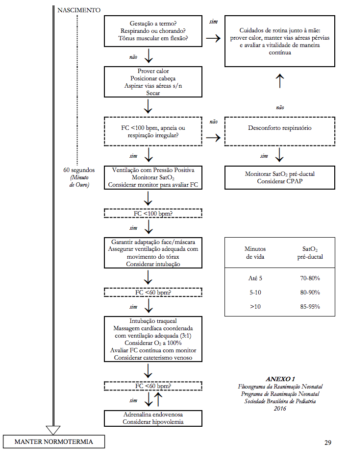

- **Referências:**

Sociedade Brasileira de Pediatria. Reanimação do recém-nascido ≥ 34 semanas em sala de parto: Diretrizes 2016 da Sociedade Brasileira de Pediatria, 2016

www.sbp.com.br/reanimacao

Responsáveis pela elaboração da rotina: Dr. Carlos Henrique Roriz da Rocha e Dra. Kátia Souza Gonçalves Silveira